# Problema 4 - Checkpoint 1

Julio Cesar Neves

13 de abril de 2016

# Pré-processando os dados e obtendo informações

Para poder realizar a regressão linear dos dados deste problema, foi necessário derivar informações a partir dos dados originais. Nesse caso, os dados que foram derivados foram a distância entre os pontos de medição do gps (em quilômetros) e o tempo de duração de cada trecho da viagem. Em posse dessas informações, foi possível calcular o percurso total de cada ônibus e o tempo total utilizado para a conclusão de cada viagem e realizar nossa regressão sobre esses dados. O código utilizado no pré-processamento dos dados pode ser encontrado em: [link](https://github.com/juliocns/problema4-ad2/blob/master/geoinfo.py) e [link](https://github.com/juliocns/problema4-ad2/blob/master/problema4.py); Algumas imagens do código podem ser vistas abaixo:

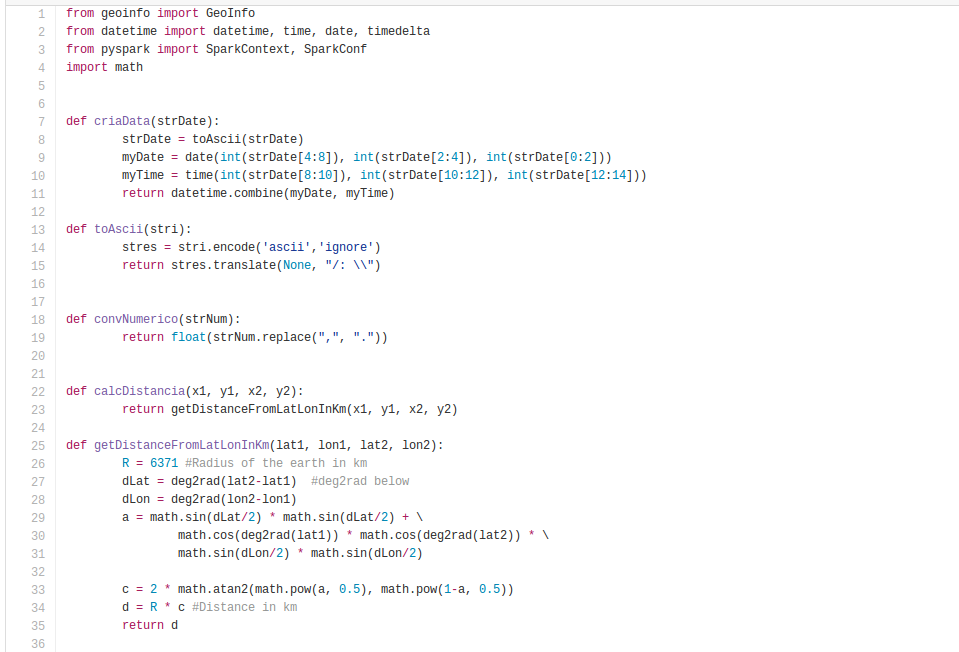

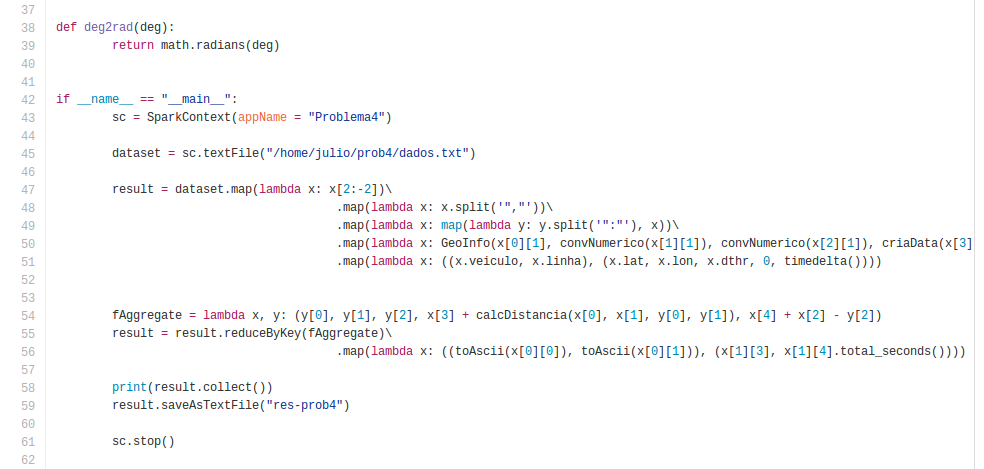

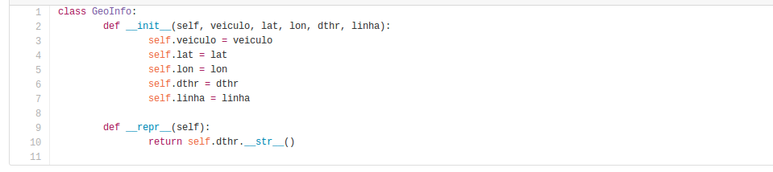

Após a execucão do script problema4.py, outro script foi executado para converter o arquivo de saída do Spark para o formato csv, que poderia ser mais facilmente utilizado em nossos cálculos.

# Obtenção do modelo

Primeiramente, é importante notar que a baixíssima quantidade de amostras fez com que o modelo não fosse tão eficiente quanto desejado.

De um total de 6 amostras, 4 foram utilizadas para o treino do modelo proposto e 2 foram usadas para testá-lo. Os detalhes do modelo obtido podem ser visualizados a seguir.

```r
library("dplyr")
library("ggplot2")
dados <- read.csv("prob4data.csv")
dados <- mutate(dados, treino = c(T, T, T, T, F, F))
treino <- filter(dados, treino == T)
modelo <- lm(tempo ~ distancia, treino)
summary(modelo)
```

```
##
## Call:
## lm(formula = tempo ~ distancia, data = treino)
##
## Residuals:
##      1      2      3      4
##   9648  -2418   6631 -13862
##
## Coefficients:
##             Estimate Std. Error t value Pr(>|t|)
## (Intercept) -29320.7    16643.6  -1.762     0.22
## distancia      756.3      211.4   3.577     0.07 .
## ---
## Signif. codes:  0 '***' 0.001 '**' 0.01 '*' 0.05 '.' 0.1 ' ' 1
##
## Residual standard error: 12940 on 2 degrees of freedom
## Multiple R-squared:  0.8648, Adjusted R-squared:  0.7973
## F-statistic:  12.8 on 1 and 2 DF,  p-value: 0.07004
```

Além disso, podemos observar a representação gráfica da reta de regressão e com base nestas informações responder a algumas perguntas interessantes.

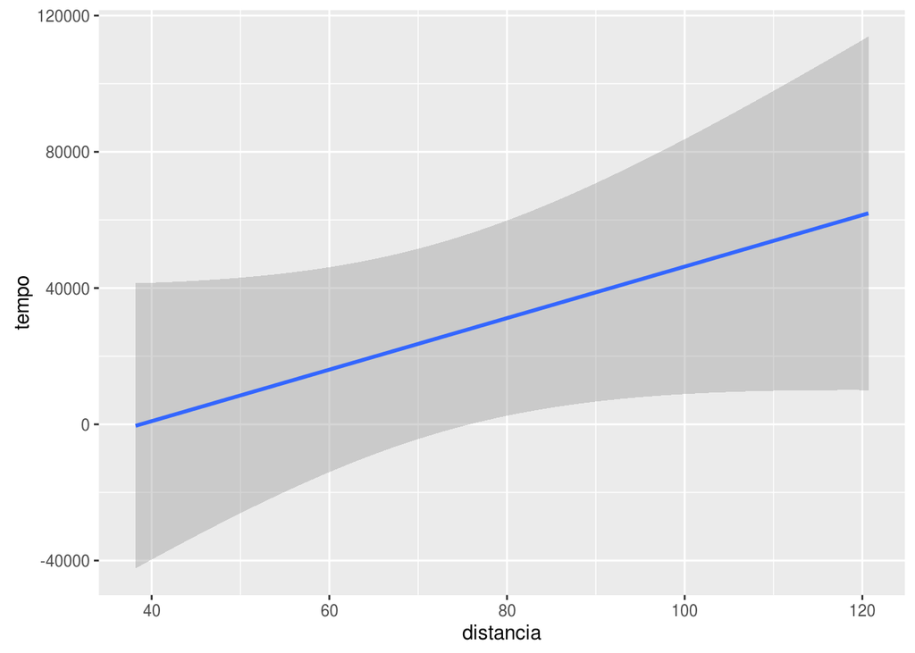

```r
ggplot(treino, aes(x = distancia, y = tempo)) + geom_smooth(method = "lm")
```

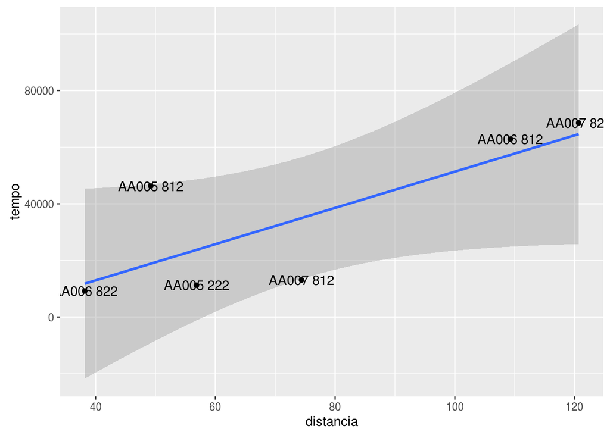

```r
distancias <- select(dados, distancia)
modelado <- predict(modelo, distancias)
dados <- mutate(dados, estimativa = modelado)
ggplot(dados, aes(x = distancia, y = tempo)) + geom_smooth(method = "lm") +
  geom_point(mapping = aes(x = distancia, y = tempo)) +
  geom_text(aes(label= paste(onibus, linha)))
```